# project

```python
#Load the necessary packages

import numpy as np
import pandas as pd
import matplotlib.pyplot as plt
import seaborn as sns
import scipy.stats as stats
```

```python
#read the data as a dataframe

insurancedata = pd.read_csv('C:/Users/vsnimmak/Downloads/insurance.csv')
```

```python
#shape of the data

insurancedata.shape
```

```
(1338, 7)
```

The shape of the data can be found using .shape , The shape of the current data type is (1338,7)

```python
#Data type of All attributes

insurancedata.info()
```

```
<class 'pandas.core.frame.DataFrame'>
RangeIndex: 1338 entries, 0 to 1337
Data columns (total 7 columns):
 #   Column    Non-Null Count  Dtype
---  ------    --------------  -----
 0   age       1338 non-null   int64
 1   sex       1338 non-null   object
 2   bmi       1338 non-null   float64
 3   children  1338 non-null   int64
 4   smoker    1338 non-null   object
 5   region    1338 non-null   object
 6   charges   1338 non-null   float64
dtypes: float64(2), int64(2), object(3)
memory usage: 73.3+ KB
```

The Data type of all the variables are listed , where age takes int64 as datatype, sex takes object as datatype, bmi takes float64 as data type,children takes int64 as data type , smoker takes object as datatype, region takes object as datatype, charges rakes float64 as datatype.

```python
#checking the presence NULL (missing) valuse in the table

insurancedata.isnull().sum()
```

```
age         0
sex         0
bmi         0
children    0
smoker      0
region      0
charges     0
dtype: int64
```

Since all the values are false (0), there are no missing values in the table

```python
#5point for numerical values

insurancedata.describe()
```

|  | age | bmi | children | charges |
| --- | --- | --- | --- | --- |
| count | 1338.000000 | 1338.000000 | 1338.000000 | 1338.000000 |
| mean | 39.207025 | 30.663397 | 1.094918 | 13270.422265 |
| std | 14.049960 | 6.098187 | 1.205493 | 12110.011237 |
| min | 18.000000 | 15.960000 | 0.000000 | 1121.873900 |
| 25% | 27.000000 | 26.296250 | 0.000000 | 4740.287150 |
| 50% | 39.000000 | 30.400000 | 1.000000 | 9382.033000 |
| 75% | 51.000000 | 34.693750 | 2.000000 | 16639.912515 |
| max | 64.000000 | 53.130000 | 5.000000 | 63770.428010 |

The 5 point for Numerical values can be found by using .describe()

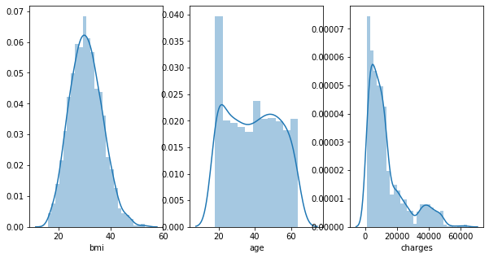

```python
#Distribution of bmi age charges

fig, ax=plt.subplots(figsize = (10,5))
plt.subplot(1,3,1)
sns.distplot(insurancedata['bmi']);
plt.subplot(1,3,2)
sns.distplot(insurancedata['age']);
plt.subplot(1,3,3)
sns.distplot(insurancedata['charges']);
```

Since the distribution for bmi is a normal distrubution and follows a bell curve. The age is not much differentiate in the list of ages. The charges follows a right skew .

```python
#Measure of Skewness of bmi age and charges
insurancedata.skew()
```

```
age         0.055673
bmi         0.284047
children    0.938380
charges     1.515880
dtype: float64
```

The Skewness of can be found by using .skew(), the skewness of bmi is 0.284047, age is 0.055673, charges is 1.515880.

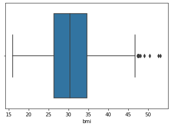

```python
#measure the outliers of bmi

sns.boxplot(insurancedata['bmi'])
```

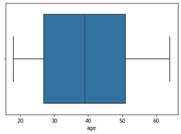

```python
#measure the outliers of age
sns.boxplot(insurancedata['age'])
```

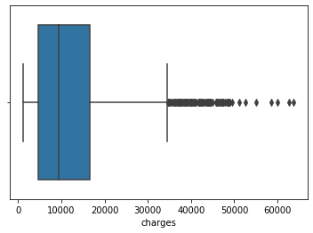

```python
#measure the outliers of charges

sns.boxplot(insurancedata['charges'])
```

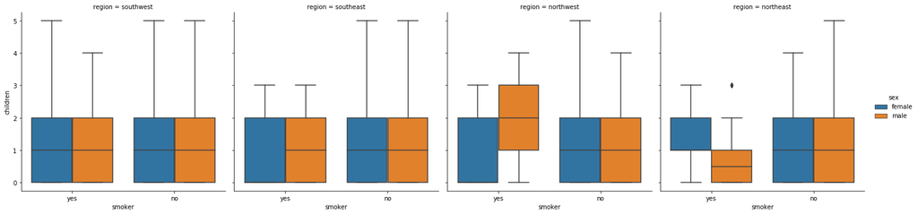

```python
#distributions of categorical data

sns.catplot(x="smoker",y="children",hue="sex",col="region",data=insurancedata,kind="box")
```

The distribution is shown in catplot, and the plots are plotted for different regions.

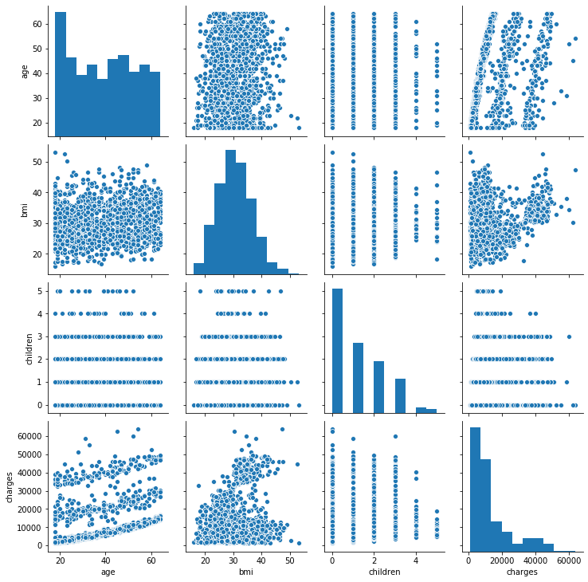

```python
#pair plot that includes all columns of the data frame.
sns.pairplot(insurancedata)
```

Alternate Hypothesis : There is significat difference between the charges of people who smoke and who dont smoke. NULL Hypothesis: There is no significant difference between the charges of people who smoke and who dont smoke.

```python
#Do charges of people who smoke differ significantly from the people who dont?

from scipy.stats import f_oneway
smoker=insurancedata[insurancedata['smoker']=='yes']
insurancedata_smoker_charges=smoker['charges']
non_smoker=insurancedata[insurancedata['smoker']=='no']
insurancedata_non_smoker_charges=non_smoker['charges']
f_oneway(insurancedata_smoker_charges,insurancedata_non_smoker_charges)
```

```
F_onewayResult(statistic=2177.614868056519, pvalue=8.271435842182967e-283)
```

Since the P value is very low, there is significant differenece between the charges of people who smoke and who dont smoke.

We Reject the NULL hypothesis , since there is significat difference between the charges of people who smoke and who dont smoke.

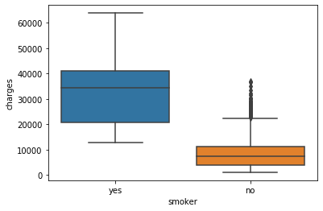

```python
sns.boxplot(x="smoker",y="charges",data=insurancedata)
```

Alternate Hypothesis : There is significant diffrence between bmi of males from that of bmi of females Null Hypothesis : There is no significant differenece between bmi of males from that of bmi of females.

```python
#Does bmi of males differ significantly from that of females?

from scipy.stats import f_oneway
males=insurancedata[insurancedata['sex']=='male']
insurancedata_males=males['bmi']
females=insurancedata[insurancedata['sex']=='female']
insurancedata_females=females['bmi']
f_oneway(insurancedata_males,insurancedata_females)
```

```
F_onewayResult(statistic=2.878969506932102, pvalue=0.08997637178992055)
```

# since the Pvalue is greater than 5% there is no significant difference between bmi of males from that of bmi of females.

```python
Alternate Hypothesis: The proportion of smokers is significantly different in different genders.
Null Hypothesis: The proportion of smokers is not significantly different in different genders.
```

```python
#Is the proportion of smokers significantly different in different genders?

male1=insurancedata.loc[insurancedata['sex']=='male']
smoker1=male1.loc[male1['smoker']=='yes']
non_smoker1=male1.loc[male1['smoker']=='no']
x=male1['smoker'].value_counts()
y=smoker1['smoker'].value_counts()
print(x,y)
```

```
no     517
yes    159
Name: smoker, dtype: int64 yes    159
Name: smoker, dtype: int64
```

```python
female1=insurancedata.loc[insurancedata['sex']=='female']
smoker1=female1.loc[female1['smoker']=='yes']
non_smoker1=female1.loc[female1['smoker']=='no']
x=female1['smoker'].value_counts()
y=smoker1['smoker'].value_counts()
print(x,y)
```

```
no     547
yes    115
Name: smoker, dtype: int64 yes    115
Name: smoker, dtype: int64
```

```python
s_array=np.array([[159,517],[115,547]])
print(stats.chi2_contingency(s_array))
```

```
(7.3929108145999605, 0.006548143503580674, 1, array([[138.43348281, 537.56651719],
       [135.56651719, 526.43348281]]))
```

Here the P value is 0.006548143503580674 which is very less than 5%, so the proportion of smokers significantly different in different genders hold true. Hence We reject the NULL hypothesis.

```python
#Is the distribution of bmi across women with no children, one child and two children, the same?

women=insurancedata.loc[insurancedata['sex']=='female']
childrens=women.loc[women['children'].isin([0,1,2])]
```

```python
from statsmodels.stats.multicomp import pairwise_tukeyhsd
print(pairwise_tukeyhsd(childrens['bmi'],childrens['children'],alpha=0.05))
```

```
Multiple Comparison of Means - Tukey HSD, FWER=0.05
===================================================
group1 group2 meandiff p-adj   lower  upper  reject
---------------------------------------------------
     0      1  -0.3089 0.8494 -1.7186 1.1008  False
     0      2   0.2883 0.8942 -1.2636 1.8402  False
     1      2   0.5971 0.6797 -1.1323 2.3265  False
---------------------------------------------------
```

Here the reject is false everywhere, the distribution of bmi across women with no children,one child and two children is same.